# L06 Data Import

Data Science 1 with R (STAT 301-1)

Author

Ryan Nguyen

## Overview

The goal of this lab is to learn the how to utilize the `readr` package, a member of the `tidyverse`, to load flat files (e.g., `csv` & `txt`) — [`readr` package home page](http://readr.tidyverse.org/articles/readr.html)

## Load Packages

```r
# Loading package(s)
library(tidyverse, quietly = T)
```

## Datasets

All datasets are either coded inline or contained in the `data` sub-directory within the downloaded zip file.

## Exercises

### Exercise 1

Demonstrate how to read in `TopBabyNamesByState.txt` contained in the `data` sub-directory using the appropriate function from `readr` package. After reading in the data, determine the top male and female names in 1984 for South Dakota.

```r
BabyNames <- read_delim("data/TopBabyNamesByState.txt", delim = "|",
                        show_col_types = FALSE)

BabyNames %>%
  filter(state == "SD", year == 1984) %>%
  head(2)
```

```
# A tibble: 2 × 5
  state gender  year top_name occurences
  <chr> <chr>  <dbl> <chr>         <dbl>
1 SD    F       1984 Jessica         166
2 SD    M       1984 Matthew         220
```

**ANSWER** The top male and female names in 1984 for South Dakota are Matthew and Jessica.

### Exercise 2

What is the main difference between `read_csv()`, `read_csv2()`, and `read_tsv()`?

They all accept the parameters `na`, `col_names`, and `trim_ws`. Please describe in your own words what each of these parameters control.

**ANSWER:** `read_csv()`, `read_csv2()`, and `read_tsv()` all read flat file data, but `read_csv()` reads comma separated values, `read_csv2()` uses ; for the field separator and , for the decimal point, and `read_tsv()` reads tab separated values. `col_names` decides the column names; if it is TRUE, the first row will be the names, if FALSE, they’ll be generated automatically, or you can input character vector of column names. `na` interprets missing values, and you can put `character()` to indicate there are no missing values. `trim_ws` decides if leading and trailing whitespace should be trimmed from every field before parsing.

### Exercise 3

Read in the fixed width file `fwf_example.txt` contained in the sub-directory `data`. We have provided the column names so the final dataset has appropriate names. You may want to look at the dataset in a text editor to get an idea of what you are dealing with. (Hint: Use `fwf_widths()` for `col_positions` and the `skip` parameter where appropriate.)

```r
# Column names.
column_names <- c(
  "Entry", "Per.", "Post Date", "GL Account", "Description", "Srce.",
  "Cflow", "Ref.", "Post", "Debit", "Credit", "Alloc."
  )
column_widths <- c(8, 4, 12, 13, 26, 6, 4, 10, 13, 19, 13, 4)
```

**ANSWER:**

```r
fwf_example <- read_fwf(file = "data/fwf_example.txt",
         col_positions = fwf_widths(widths = column_widths,
                                    col_names = column_names),
         skip = 2,
         show_col_types = FALSE)
fwf_example
```

```
# A tibble: 17 × 12
    Entry Per.  Post Da…¹ GL Ac…² Descr…³ Srce. Cflow Ref.  Post   Debit  Credit
    <dbl> <chr> <chr>       <dbl> <chr>   <chr> <chr> <chr> <chr>  <dbl>   <dbl>
 1  16524 01    10/17/20…  3.93e9 TXNPUES S1    Yes   RHMX… Yes     NA    5.01e3
 2 191675 01    01/14/20…  2.37e9 OUNHQE… S1    No    <NA>  Yes     NA    4.35e4
 3 191667 01    01/14/20…  3.71e9 GHAKAS… S1    Yes   <NA>  Yes   3173.  NA
 4 191673 01    01/14/20…  2.63e9 PAHFSA… S1    No    <NA>  Yes    983.  NA
 5  80495 01    11/21/20…  2.77e9 XDZANTV S1    Yes   TGZG… Yes     NA    9.04e2
 6  80507 01    11/21/20…  4.61e9 BWWYEZL S1    Yes   USUK… Yes     NA    6.70e2
 7  80509 01    11/21/20…  1.09e9 QJYPKVO S1    No    DNUN… Yes     NA    8.48e2
 8  80497 01    11/21/20…  3.39e9 SOQLCMU S1    Yes   BRHU… Yes     NA    7.31e0
 9 191669 01    01/14/20…  5.91e9 FYIWNK… S1    Yes   <NA>  Yes   9168.  NA
10 191671 01    01/14/20…  2.75e9 CBMJTL… S1    Yes   <NA>  Yes    747.  NA
11 191674 01    01/14/20…  4.53e9 OTAVZG… S1    Yes   <NA>  No    7036.  NA
12 244819 01    02/04/20…  4.68e9 EGHLQT… S1    Yes   <NA>  No      NA    8.99e4
13  96062 01    11/30/20…  6.00e9 KTSVTA… S1    Yes   UBNQ… Yes      7.1 NA
14  16527 01    10/17/20…  5.60e9 ILCVJYC S1    Yes   HCVZ… Yes     NA    3.21e2
15 191670 01    01/14/20…  1.95e9 RPPDCW… S1    Yes   <NA>  No    9294.  NA
16 191672 01    01/14/20…  4.94e9 CTMDXX… S1    Yes   <NA>  No     175   NA
17 191668 01    01/14/20…  4.21e9 DBZZUL… S1    Yes   <NA>  Yes    206.  NA
# … with 1 more variable: Alloc. <chr>, and abbreviated variable names
#   ¹`Post Date`, ²`GL Account`, ³Description
```

### Exercise 4

Generate the correct format string to parse each of the following dates and times:

```r
# various date and time string formats
d1 <- "January 1, 2010"
d2 <- "2015-Mar-07"
d3 <- "06-Jun-2017"
d4 <- c("August 19 (2015)", "July 1 (2015)")
d5 <- "12/30/14" # Dec 30, 2014
t1 <- "1705"
t2 <- "11:15:10.12 PM"
```

**ANSWER:**

```r
parse_date(d1, "%B %d, %Y")
```

```
[1] "2010-01-01"
```

```r
parse_date(d2, "%Y-%b-%d")
```

```
[1] "2015-03-07"
```

```r
parse_date(d3, "%d-%b-%Y")
```

```
[1] "2017-06-06"
```

```r
parse_date(d4, "%B %d (%Y)")
```

```
[1] "2015-08-19" "2015-07-01"
```

```r
parse_date(d5, "%m/%d/%y")
```

```
[1] "2014-12-30"
```

```r
parse_time(t1, "%H%M")
```

```
17:05:00
```

```r
parse_time(t2, "%I:%m:%OS %p")
```

```
23:00:10.12
```

### Exercise 5

Read in and store `cdc.txt` from the `data` sub-directory.

- Create a graphic that compares the distribution of weights for each gender.
- Write out a copy of the dataset to the `data` sub-directory as a tab deliminated text file named `cdc_tab.txt`.
- Write out a copy of the dataset to the `data` sub-directory as an RDS file named `cdc.rds`.
- List some benefits of writing a dataset to an RDS file type.

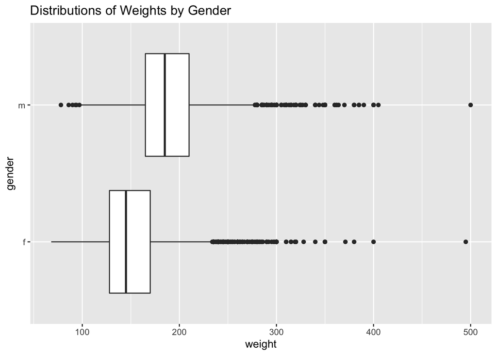

```r
cdc <- read_delim("data/cdc.txt", show_col_types = FALSE)

ggplot(cdc, aes(x = weight, y = gender)) +
  geom_boxplot() +
  labs(title = "Distributions of Weights by Gender")
```

```r
write_tsv(cdc, "data/cdc_tab.txt")

write_rds(cdc, "data/cdc.rds")
```

**ANSWER:** An RDS file type is normally smaller than a text file, which means it takes up less storage space and it is quicker to load. It also preserves data types and classes, getting rid of the need to redefine them after loading the file. Lastly, RDS supports list-columns, while some types do not.

### Exercise 6

What types of files do the packages `haven` and `readxl` deal with?

**ANSWER:** `haven` reads SPSS, Stata, and SAS files, and `readxl` reads both excel files (.xls and .xlsx).

### Exercise 7

What function in `janitor` helps you deal with non-syntactic column names in R and and also ensures column names are systematically handled? Demonstrate its use.

**ANSWER:** The `clean_names()` function helps us deal with non-syntactic column names in R and ensures column names are systematically handled.

```r
annoying <- tibble(
  `1` = 1:10,
  `2` = `1` * 2 + rnorm(length(`1`))
  )

annoying
```

```
# A tibble: 10 × 2
     `1`    `2`
   <int>  <dbl>
 1     1  0.916
 2     2  3.44
 3     3  5.74
 4     4  6.94
 5     5  9.39
 6     6 12.3
 7     7 14.2
 8     8 16.1
 9     9 17.1
10    10 19.3
```

```r
annoying2 <- tibble(
  `1` = 1:10,
  `2` = `1` * 2 + rnorm(length(`1`))
  ) %>%
  janitor::clean_names()

annoying2
```

```
# A tibble: 10 × 2
      x1    x2
   <int> <dbl>
 1     1  1.04
 2     2  4.14
 3     3  7.09
 4     4  7.46
 5     5 11.1
 6     6 12.1
 7     7 14.3
 8     8 15.1
 9     9 17.1
10    10 18.9
```

### Exercise 8

Suppose a data file takes a long time to read in, which can be a problem since we will need to read it in every time we come back to work on it. How could you increase the read in speed of this dataset for future R sessions?

**ANSWER:**

One way to increase the read in speed of this dataset is to save it as an RDS. This will make it load in quicker since it’s smaller, and it will preserve the data types. You can also use `read_lines()` to just read into a character vector of lines or even a character vector of length 1 with `read_file`.

## Challenge

**Required for graduate students, but not for undergraduate students.**

Extract 2016 total population estimates for each state and DC from `cc-est2016-alldata.csv` contained in the `data` subdirectory. Force RStudio to display all rows and have them arranged from largest to smallest in population.

*Hint: May want to read the `cc-est2016-alldata.pdf` for details.*